# Project3-Markdown

Bartosz Slysz

2024-01-12

# **Music & Mental Health Survey - association rules mining.**

The goal of this project is to determine the relations between favorite music genres, music listening habits and self-reported assessment of mental health of questionnaire attendees with the help of association rules mining methodology.

The source of the data is: https://www.kaggle.com/datasets/catherinerasgaitis/mxmh-survey-results

The concept of using the association rules mining on the survey result was derived from the lecture example of analysis of the general survey of happiness of inhabitants of the city of Sommerville.  
I have briefly checked a few of the best notebooks under this Kaggle topic and after not finding association rules implementation have decided to explore this niche.

## Measures to be used.

### Support.

The support of an association rule is determined by the proportion of groups containing all items specified in the rule. This percentage is calculated based on the total number of considered groups, indicating the frequency with which both the rule body (antecedent) and rule head (consequent) appear together among all considered groups.

### Confidence.

The confidence of an association rule is expressed as a percentage, reflecting the frequency with which the rule head appears in groups that also contain the rule body. This confidence value serves as a measure of the rule’s reliability. A higher confidence value indicates a greater likelihood of the head items appearing in a group when it is known that all the body items are present in that group.

### Lift.

The lift value allows to quantify importance of a rule. It is determined by the ratio of the rule’s confidence to its expected confidence. The expected confidence is calculated by dividing the product of the support values for the rule body and rule head by the support of the rule body.

A lift value above 1 implies a positive association, indicating that the rule body and rule head occur more frequently together than expected. A lift below 1 suggests a negative association, meaning the rule body and rule head appear less often together than expected. A lift around 1 signifies a neutral association, with the occurrences aligning closely to expectations.

## Data preparation.

### Cleaning.

```r
library(tidyverse)
data = read.csv('mxmh_survey_results.csv')
str(data)
```

```
## 'data.frame':    736 obs. of  33 variables:
##  $ Timestamp                   : chr  "8/27/2022 19:29:02" "8/27/2022 19:57:31" "8/27/2022 21:28:18" "8/27/2022 21:40:40" ...
##  $ Age                         : int  18 63 18 61 18 18 18 21 19 18 ...
##  $ Primary.streaming.service   : chr  "Spotify" "Pandora" "Spotify" "YouTube Music" ...
##  $ Hours.per.day               : num  3 1.5 4 2.5 4 5 3 1 6 1 ...
##  $ While.working               : chr  "Yes" "Yes" "No" "Yes" ...
##  $ Instrumentalist             : chr  "Yes" "No" "No" "No" ...
##  $ Composer                    : chr  "Yes" "No" "No" "Yes" ...
##  $ Fav.genre                   : chr  "Latin" "Rock" "Video game music" "Jazz" ...
##  $ Exploratory                 : chr  "Yes" "Yes" "No" "Yes" ...
##  $ Foreign.languages           : chr  "Yes" "No" "Yes" "Yes" ...
##  $ BPM                         : int  156 119 132 84 107 86 66 95 94 155 ...
##  $ Frequency..Classical.       : chr  "Rarely" "Sometimes" "Never" "Sometimes" ...
##  $ Frequency..Country.         : chr  "Never" "Never" "Never" "Never" ...
##  $ Frequency..EDM.             : chr  "Rarely" "Never" "Very frequently" "Never" ...
```

[output cut: 19 more lines]

The data for further analysis has to be converted to the categorical data. Firstly, the columns time-stamp, primary streaming service, BPM and permissions are dropped as they will not be useful.

```r
columnsToDismiss = c(1, 3, 11, 33)
data = data[, -columnsToDismiss]
```

```r
summary(data)
```

```
##       Age        Hours.per.day    While.working      Instrumentalist
##  Min.   :10.00   Min.   : 0.000   Length:736         Length:736
##  1st Qu.:18.00   1st Qu.: 2.000   Class :character   Class :character
##  Median :21.00   Median : 3.000   Mode  :character   Mode  :character
##  Mean   :25.21   Mean   : 3.573
##  3rd Qu.:28.00   3rd Qu.: 5.000
##  Max.   :89.00   Max.   :24.000
##  NA's   :1
##    Composer          Fav.genre         Exploratory        Foreign.languages
##  Length:736         Length:736         Length:736         Length:736
##  Class :character   Class :character   Class :character   Class :character
##  Mode  :character   Mode  :character   Mode  :character   Mode  :character
##
##
##
##
##  Frequency..Classical. Frequency..Country. Frequency..EDM.
##  Length:736            Length:736          Length:736
##  Class :character      Class :character    Class :character
##  Mode  :character      Mode  :character    Mode  :character
##
##
##
##
##  Frequency..Folk.   Frequency..Gospel. Frequency..Hip.hop. Frequency..Jazz.
##  Length:736         Length:736         Length:736          Length:736
##  Class :character   Class :character   Class :character    Class :character
##  Mode  :character   Mode  :character   Mode  :character    Mode  :character
##
##
##
##
##  Frequency..K.pop.  Frequency..Latin.  Frequency..Lofi.   Frequency..Metal.
##  Length:736         Length:736         Length:736         Length:736
##  Class :character   Class :character   Class :character   Class :character
##  Mode  :character   Mode  :character   Mode  :character   Mode  :character
##
##
##
##
```

[output cut: 9 more lines]

```
##  Length:736                   Min.   : 0.000   Min.   : 0.000
##  Class :character             1st Qu.: 4.000   1st Qu.: 2.000
##  Mode  :character             Median : 6.000   Median : 5.000
##                               Mean   : 5.838   Mean   : 4.796
##                               3rd Qu.: 8.000   3rd Qu.: 7.000
##                               Max.   :10.000   Max.   :10.000
##
##     Insomnia           OCD         Music.effects
##  Min.   : 0.000   Min.   : 0.000   Length:736
##  1st Qu.: 1.000   1st Qu.: 0.000   Class :character
##  Median : 3.000   Median : 2.000   Mode  :character
##  Mean   : 3.738   Mean   : 2.637
##  3rd Qu.: 6.000   3rd Qu.: 5.000
##  Max.   :10.000   Max.   :10.000
##
```

```r
# removing rows with NA's (only one row without age)

data = data[complete.cases(data),]
```

The data that could be divided into some meaningful category bins is subjectively converted into ones to allow for further rules mining. In terms of the age, I have designed bins grid to be quite tight due to data distribution into quartiles (vide above summary). For other variables the grid was designed to be simple.

```r
# columns with continuous data need introduction of categorical bins

data$Age <- factor(ifelse(data$Age < 18, "Age < 18",
                      ifelse(data$Age <= 24, "Age 18-24",
                      ifelse(data$Age <= 34, "Age 25-34",
                      ifelse(data$Age <= 44, "Age 35-44",
                      ifelse(data$Age <= 54, "Age 45-54",
                      ifelse(data$Age <= 64, "Age 55-64",
                      ifelse(data$Age >= 65, "Age 65+", NA))))))),
                      levels = c("Age < 18", "Age 18-24", "Age 25-34", "Age 35-44", "Age 45-54", "Age 55-64", "Age 65+"))

data$Hours.per.day <- factor(ifelse(data$Hours.per.day <= 2, 'hours <= 2',
                            ifelse(data$Hours.per.day <= 4, '2 < hours <= 4',
                            ifelse(data$Hours.per.day <= 6, '4 < hours <= 6',
                            ifelse(data$Hours.per.day <= 24, '6+ hours', NA)))),
                            levels = c('hours <= 2', '2 < hours <= 4', '4 < hours <= 6', '6+ hours'))

data$Anxiety <- factor(ifelse(data$Anxiety < 4, "Not Anxious",
                       ifelse(data$Anxiety < 7, "Fairly Anxious",
                        ifelse(data$Anxiety < 11, "Anxious", NA))),
                        levels = c("Not Anxious", "Fairly Anxious", "Anxious"))

data$Depression <- factor(ifelse(data$Depression < 4, "Not Depressed",
                          ifelse(data$Depression < 7, "Fairly Depressed",
                          ifelse(data$Depression < 11, "Depressed", NA))),
                          levels = c("Not Depressed", "Fairly Depressed", "Depressed"))

data$Insomnia <- factor(ifelse(data$Insomnia < 4, "Not Insomniac",
                        ifelse(data$Insomnia < 7, "Fairly Insomniac",
                        ifelse(data$Insomnia < 11, "Insomniac", NA))),
                        levels = c("Not Insomniac", "Fairly Insomniac", "Insomniac"))

data$OCD <- factor(ifelse(data$OCD < 4, "Not O-C",
                  ifelse(data$OCD < 7, "Fairly O-C",
                  ifelse(data$OCD < 11, "O-C", NA))),
                  levels = c("Not O-C", "Fairly O-C", "O-C"))
```

The data with the ‘yes or no’ answers, touching the matter of listener’s habits, was also converted, so that in the case of displaying the values in the basket analysis it will be clearly interpretable.

```r
### YES/NO Questions modification.

data$While.working = ifelse(data$While.working == 'Yes', "Listening while working", ifelse(data$While.working == 'No', "Not listening while working", NA))

data$Instrumentalist = ifelse(data$Instrumentalist == 'Yes', "Instrumentalist", ifelse(data$Instrumentalist == 'No', "Non-instrumentalist", NA))

data$Composer = ifelse(data$Composer == 'Yes', "Composer", ifelse(data$Composer == 'No', "Non-composer", NA))

data$Exploratory = ifelse(data$Exploratory == 'Yes', "Exploring", ifelse(data$Exploratory == 'No', "Non-exploring", NA))

data$Foreign.languages = ifelse(data$Foreign.languages == 'Yes', "Not Fluent", ifelse(data$Foreign.languages == 'No', "Only fluent", NA))
```

Final choice of columns to analyze is based on listening habits, age and mental health status. All columns related to each genres frequency are omitted. Data, after cleaning and adjustment, is saved to ‘middle file’.

```r
# columns do not need further actions despite conversion to factors
data = data %>% mutate(across(all_of(colnames(data)), factor))

dataHabitsHealth = data[, c(1:8, 25:28)]
write.csv(dataHabitsHealth, file = 'cleanData.csv')
```

### Insights from statistics.

#### Age and listening hours.

The most popular age groups are generally young people, accordingly 18 to 24, below 18 and between 25 and 34 years old.

```r
library(arules)
```

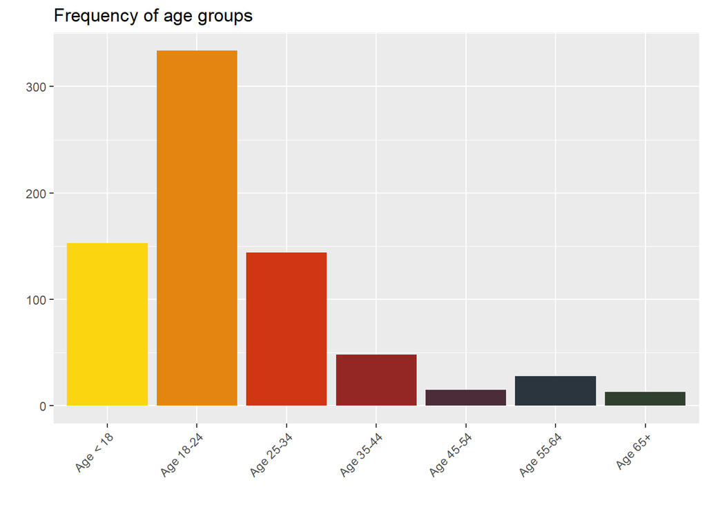

```r
library(wesanderson)

ggplot(dataHabitsHealth, aes(x = Age, fill = Age)) +
  geom_bar() +
  theme(axis.text.x = element_text(angle = 45, hjust = 1), legend.position = 'none') +
  labs(title = "Frequency of age groups", y='', x='') +
  scale_x_discrete(labels = levels(dataHabitsHealth$Age))+
  scale_fill_manual(values = wes_palette(('BottleRocket2'),10,type=c('continuous')))
```

Almost half of surveyed people spend less than 2 hours per day on listening to music.

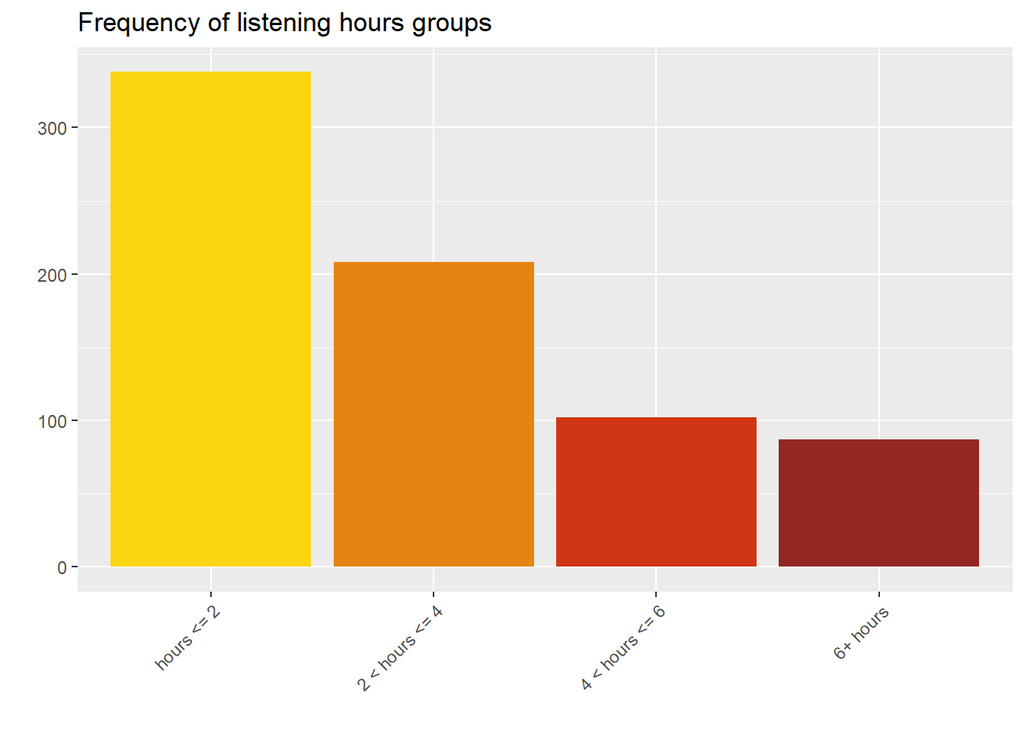

```r
ggplot(dataHabitsHealth, aes(x = Hours.per.day, fill=Hours.per.day))+
  geom_bar() +
  theme(axis.text.x = element_text(angle=45, hjust=1), legend.position = 'none') +
  labs(title = "Frequency of listening hours groups", y='', x='') +
  scale_x_discrete(labels = levels(dataHabitsHealth$Hours.per.day))+
  scale_fill_manual(values = wes_palette(('BottleRocket2'),10,type=c('continuous')))
```

#### Mental Health summary.

Brief numeric summary of mental health self-assessment.

```r
summary(dataHabitsHealth$Anxiety)
```

```
##    Not Anxious Fairly Anxious        Anxious
##            177            198            360
```

```r
summary(dataHabitsHealth$Depression)
```

```
##    Not Depressed Fairly Depressed        Depressed
##              277              202              256
```

```r
summary(dataHabitsHealth$Insomnia)
```

```
##    Not Insomniac Fairly Insomniac        Insomniac
##              387              179              169
```

```r
summary(dataHabitsHealth$OCD)
```

```
##    Not O-C Fairly O-C        O-C
##        503        136         96
```

#### What are top 5 favorite genres?

5 most popular music genres Rock (188), Pop (114), Metal (88), Classical (53) and video game music (44).

```r
table(dataHabitsHealth$Fav.genre)
```

```
##
##        Classical          Country              EDM             Folk
##               53               25               37               30
##           Gospel          Hip hop             Jazz            K pop
##                6               34               20               26
##            Latin             Lofi            Metal              Pop
##                3               10               88              114
##              R&B              Rap             Rock Video game music
##               35               22              188               44
```

## Association rules.

```r
transactions = read.transactions('cleanData.csv', format='basket', sep=',', skip=0)
```

Preliminary set of rules is set on very high levels of support and confidence

```r
basicRules = apriori(data = transactions, parameter=list(supp=0.55, conf=0.6))
```

```
## Apriori
##
## Parameter specification:
##  confidence minval smax arem  aval originalSupport maxtime support minlen
##         0.6    0.1    1 none FALSE            TRUE       5    0.55      1
##  maxlen target  ext
##      10  rules TRUE
##
## Algorithmic control:
##  filter tree heap memopt load sort verbose
##     0.1 TRUE TRUE  FALSE TRUE    2    TRUE
##
## Absolute minimum support count: 404
##
## set item appearances ...[0 item(s)] done [0.00s].
## set transactions ...[794 item(s), 736 transaction(s)] done [0.00s].
## sorting and recoding items ... [5 item(s)] done [0.00s].
## creating transaction tree ... done [0.00s].
## checking subsets of size 1 2 3 done [0.00s].
## writing ... [15 rule(s)] done [0.00s].
## creating S4 object  ... done [0.00s].
```

The results for such levels of support and confidence are either trivial (non-instrumentalist => non-composer) or not meaningful, which was not a surprise, as high level of support indicates very high frequency of appearance in the data set.

```r
inspect(sort(basicRules, by = "lift")[1:5], linebreak = FALSE)
```

```
##     lhs                          rhs                       support   confidence
## [1] {Non-instrumentalist}     => {Non-composer}            0.6290761 0.9334677
## [2] {Non-composer}            => {Non-instrumentalist}     0.6290761 0.7615132
## [3] {Exploring}               => {Listening while working} 0.5855978 0.8225191
## [4] {Listening while working} => {Exploring}               0.5855978 0.7456747
## [5] {Not O-C}                 => {Non-composer}            0.5665761 0.8290258
##     coverage  lift     count
## [1] 0.6739130 1.129987 463
## [2] 0.8260870 1.129987 463
## [3] 0.7119565 1.047360 431
## [4] 0.7853261 1.047360 431
## [5] 0.6834239 1.003558 417
```

### Anxiety as antecedent.

```r
rulesAnxious = apriori(data=transactions, parameter=list(supp=0.05, conf=0.35, minlen=2), appearance=list(default="rhs", lhs="Anxious"), control=list(verbose=F))
```

```r
rulesAnxiousSorted = sort(rulesAnxious, by="lift", decreasing=TRUE)
inspect(head(rulesAnxiousSorted))
```

```
##     lhs          rhs                       support   confidence coverage
## [1] {Anxious} => {Depressed}               0.2513587 0.5138889  0.4891304
## [2] {Anxious} => {Not Fluent}              0.2771739 0.5666667  0.4891304
## [3] {Anxious} => {Age 18-24}               0.2282609 0.4666667  0.4891304
## [4] {Anxious} => {Listening while working} 0.3872283 0.7916667  0.4891304
## [5] {Anxious} => {Non-composer}            0.4035326 0.8250000  0.4891304
## [6] {Anxious} => {Exploring}               0.3464674 0.7083333  0.4891304
##     lift      count
## [1] 1.4774306 185
## [2] 1.0349049 204
## [3] 1.0283433 168
## [4] 1.0080738 285
## [5] 0.9986842 297
## [6] 0.9949109 255
```

[output not shown]

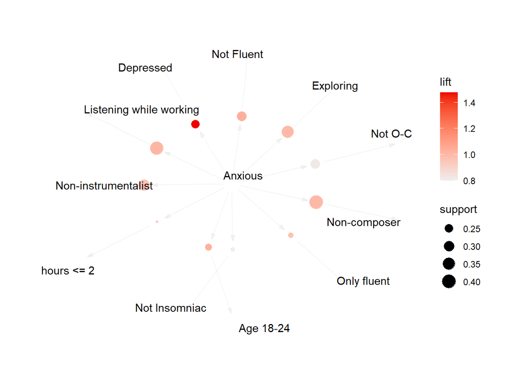

```r
library(arulesViz)
set.seed(123)

plot(rulesAnxious, method="graph", measure="support", shading="lift", main="Graph for anxiety")
```

### Depression as consequent.

There is no surprise in the results, that anxiety is always an antecedent to depression. There seems to be a positive relation between exploring for new artists/genres and depression which might indicate searching for new stimuli. There also is a positive relation, due to above 1 lift values, between listening to music while working and depression.

```r
rulesDepressed = apriori(data=transactions, parameter=list(supp=0.15, conf=0.5, minlen=2), appearance=list(default="lhs", rhs="Depressed"), control=list(verbose=F))

rulesDepressedSorted = sort(rulesDepressed, by="lift", decreasing=TRUE)
inspect(head(rulesDepressedSorted))
```

```
##     lhs                          rhs           support confidence  coverage     lift count
## [1] {Anxious,
##      Not Fluent}              => {Depressed} 0.1508152  0.5441176 0.2771739 1.564338   111
## [2] {Anxious,
##      Exploring,
##      Listening while working} => {Depressed} 0.1535326  0.5305164 0.2894022 1.525235   113
## [3] {Anxious,
##      Listening while working} => {Depressed} 0.2051630  0.5298246 0.3872283 1.523246   151
## [4] {Anxious,
##      Exploring}               => {Depressed} 0.1820652  0.5254902 0.3464674 1.510784   134
## [5] {Anxious,
##      Non-instrumentalist}     => {Depressed} 0.1657609  0.5236052 0.3165761 1.505365   122
## [6] {Anxious,
##      Non-composer,
##      Non-instrumentalist}     => {Depressed} 0.1562500  0.5227273 0.2989130 1.502841   115
```

[output not shown]

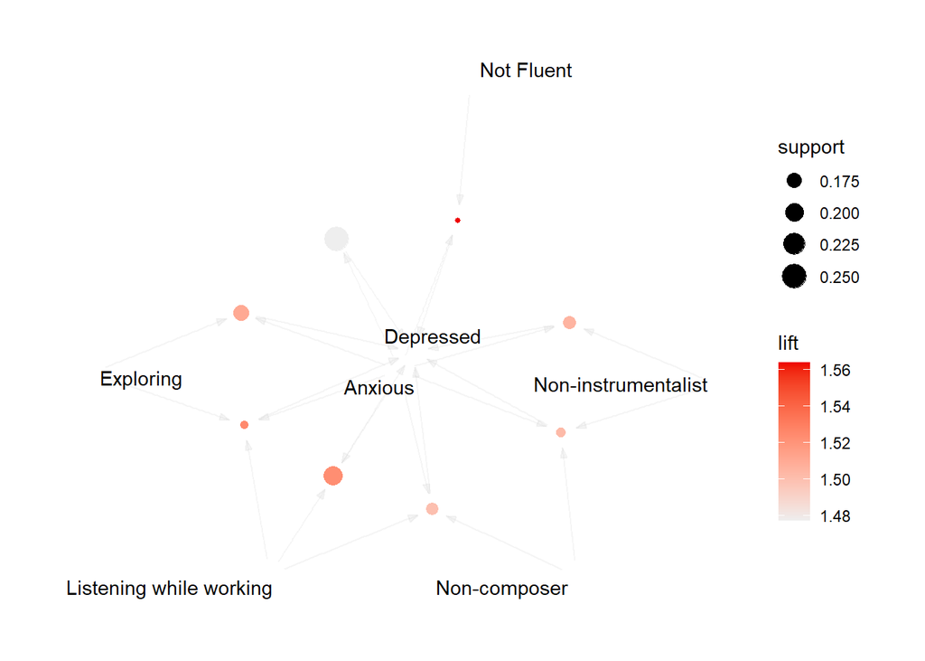

```r
set.seed(123)
plot(rulesDepressed, method="graph", measure="support", shading="lift", main="Graph for depression")
```

### Rock music as antecedent.

```r
rulesRock = apriori(data=transactions, parameter=list(supp=0.01, conf=0.3, minlen=2), appearance=list(default="rhs", lhs="Rock"), control=list(verbose=F))

rulesRockSorted = sort(rulesRock, by="lift", decreasing=TRUE)
inspect(head(rulesRockSorted))
```

```
##     lhs       rhs                   support    confidence coverage  lift
## [1] {Rock} => {Only fluent}         0.13858696 0.5425532  0.2554348 1.217436
## [2] {Rock} => {Depressed}           0.10597826 0.4148936  0.2554348 1.192819
## [3] {Rock} => {Anxious}             0.14402174 0.5638298  0.2554348 1.152719
## [4] {Rock} => {Non-exploring}       0.07880435 0.3085106  0.2554348 1.076132
## [5] {Rock} => {Non-instrumentalist} 0.18206522 0.7127660  0.2554348 1.057653
## [6] {Rock} => {Non-composer}        0.21603261 0.8457447  0.2554348 1.023796
##     count
## [1] 102
## [2]  78
## [3] 106
## [4]  58
## [5] 134
## [6] 159
```

[output not shown]

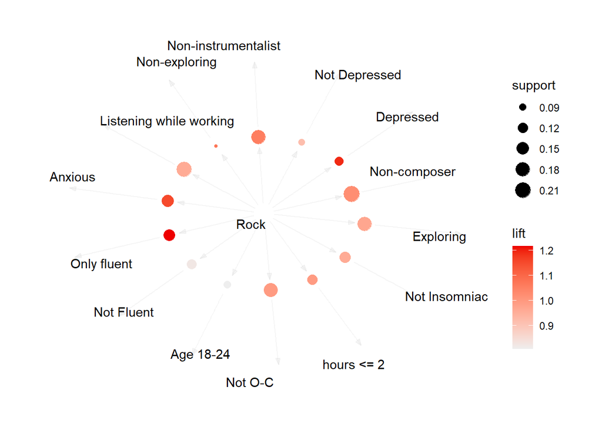

```r
set.seed(123)
plot(rulesRock, method="graph", measure="support", shading="lift", main="Graph for rock music")
```

### Classical music as consequent.

According to the result there is a high possibility that people that are listening to classical music, are in quite good mental condition, antecedents for classical music are statuses like Not Anxious, Not Depressed, Not Insomniac, Not O-C. What also is worth noticing is that classical music listeners are rather not exploring for new genres or artists. Obviously, they are also very likely to be playing instruments.

```r
rulesClassical = apriori(data=transactions, parameter=list(supp=0.01, conf=0.3, minlen=2), appearance=list(default="lhs", rhs="Classical"), control=list(verbose=F))

rulesClassicalSorted = sort(rulesClassical, by="lift", decreasing=TRUE)
inspect(head(rulesClassicalSorted))
```

```
##     lhs                           rhs            support confidence   coverage     lift count
## [1] {Instrumentalist,
##      Non-exploring,
##      Not Insomniac,
##      Only fluent}              => {Classical} 0.01086957  0.3809524 0.02853261 5.290207     8
## [2] {Instrumentalist,
##      Not Anxious,
##      Not Depressed,
##      Not Insomniac,
##      Only fluent}              => {Classical} 0.01086957  0.3809524 0.02853261 5.290207     8
## [3] {Instrumentalist,
##      Non-exploring,
##      Not O-C,
##      Only fluent}              => {Classical} 0.01222826  0.3750000 0.03260870 5.207547     9
## [4] {Instrumentalist,
##      Not Anxious,
##      Not Insomniac,
##      Only fluent}              => {Classical} 0.01086957  0.3636364 0.02989130 5.049743     8
## [5] {Instrumentalist,
##      Non-exploring,
##      Only fluent}              => {Classical} 0.01494565  0.3548387 0.04211957 4.927572    11
## [6] {Instrumentalist,
##      Listening while working,
##      Non-exploring,
##      Only fluent}              => {Classical} 0.01086957  0.3333333 0.03260870 4.628931     8
```

[output not shown]

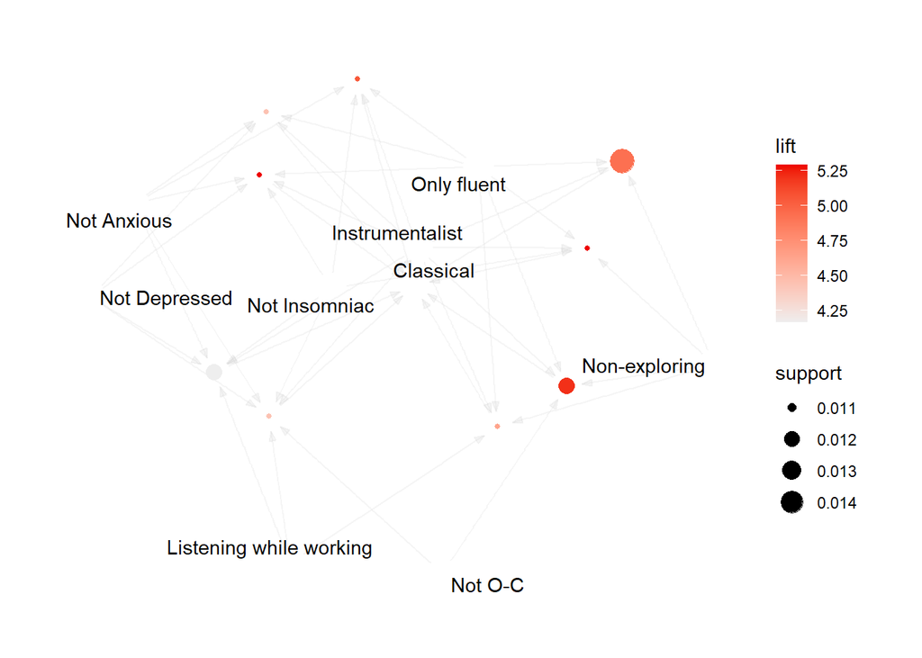

```r
set.seed(123)
plot(rulesClassical, method="graph", measure="support", shading="lift", main="Graph for classical music")
```

## Conclusions.

The association rules allow for finding some behavioral relations. I believe that their usage for mining survey results could be very effective in establishing insightful relationships in the respondents answers. Possible ways to further expand this research might be trying to find existing relations for other music genres, listening habits and mental health conditions.

## References.

Data:

https://www.kaggle.com/datasets/catherinerasgaitis/mxmh-survey-results/data

Explanation of support:

https://www.ibm.com/docs/en/db2/10.1.0?topic=associations-support-in-association-rule

Explanation of confidence:

https://www.ibm.com/docs/en/db2/10.1.0?topic=associations-confidence-in-association-rule

Explanation of lift:

https://www.ibm.com/docs/en/db2/10.1.0?topic=associations-lift-in-association-rule